# Problem Set 09

## NMDS

**Q8** Create a plot that shows the metaMDS results from `k=2`. Make sure to label the plots and birds. What does this plot tell you? Are there some birds that appear to inhabit more similar plots and some that appear to inhabit different plots? If so, which ones?

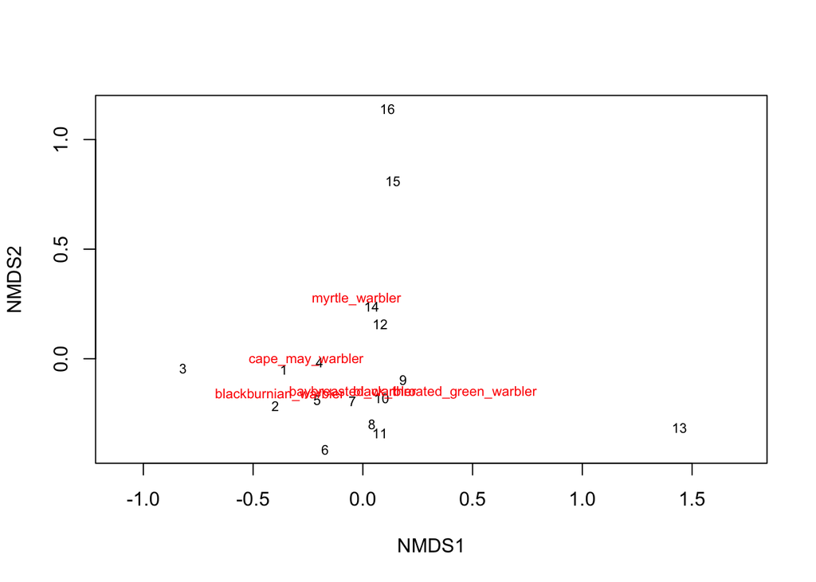

```r
plot(birds.mds2, type = "t")
```

```r
# Plots 15, 16, and 13 seem to be really different from the rest
#   of the other plots. Also, the myrtle_warbler seems the most
#   different in terms of habitat use as opposed to the other birds,
#   and the blackburnian, blackthroated green, and baybreasted
#   warblers are the most similar to each other.
```

**Q9** Create the same plot as for 7, but with a jaccard distance matrix (same dimenion level, using the presence/absence standardized data). Describe the difference between this plot and that from Question 7. How does a different standardization and distance method affect the nMDS visualization outcome?

```r
birds.mds2j <- metaMDS(birds.pa, k = 2, distance = 'jaccard', autotransform = F,
expand = F)
```

```
## *** Best solution was not repeated -- monoMDS stopping criteria:
##      3: no. of iterations >= maxit
##     17: stress < smin
```

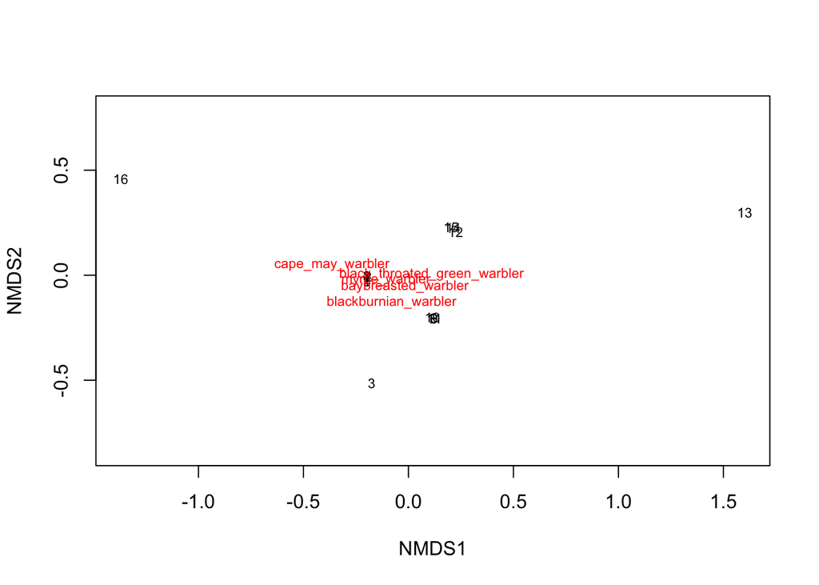

```r
plot(birds.mds2j, type = "t")
```

```r
# Here, plots 16 and 13 are still different from the rest of the plots
#   but all the birds tend to cluster together and seem to be occupying the
#   same habitat type. This is occuring because when you simply use if a
#   bird is present or not in a site, it is upweighting rare events and
#   making the equivalent to common ones, and thus makes it seem like all
#   sites are equally occupied by all birds. So what this means is that
#   all birds go to most of the same habitats at least once, but they
#   may not spend most of their time there.
```

## Environmental Fit

**Q10** Going back to the visualization from Question 7, where we used Bray-Curtis distance and `k=2`. Create an environmental fit (using `envfit()`) for the last 2 columns in the original dataset that describe the zone and height that the birds inhabit.

```r
birds.env <- birds[,7:8]
birds.env
```

```
## # A tibble: 16 × 2
##    zone     height
##    <chr>     <dbl>
##  1 terminal      6
##  2 mid           6
##  3 base          6
##  4 terminal      5
##  5 mid           5
##  6 base          5
##  7 terminal      4
##  8 mid           4
##  9 base          4
## 10 terminal      3
## 11 mid           3
## 12 base          3
## 13 terminal      2
## 14 mid           2
## 15 base          2
## 16 under         1
```

```r
birds.efit <- envfit(birds.mds2, birds.env, na.rm=TRUE)
```

**Q11** Create a triplot for this environmental fit. Describe the figure and the direction of the two environmental variables.

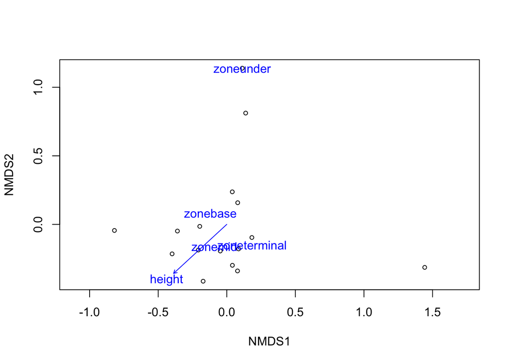

```r
plot(birds.mds2, disp = "sites")
plot(birds.efit)
```

```r
## Taller parts of the tree tend to be at the bottom left of
#   the graph, whereas lower parts of the tree at are the upper
#   right. And the "under" zone is at the top of the figure, and
#   the rest of the zones are clustered toward the bottom.
```

**Q12** Create a triplot that shows the surface for the Cape May warbler, and describe the figure.

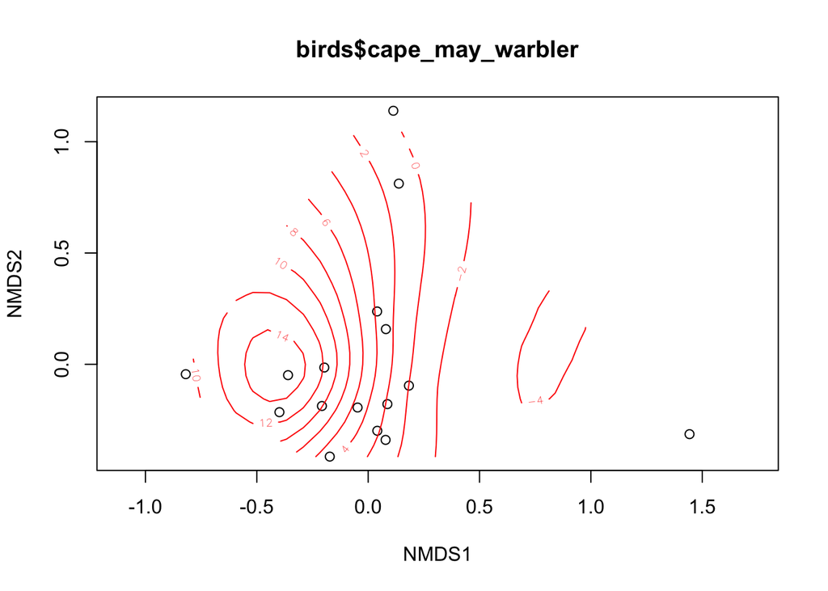

```
##
## Family: gaussian
## Link function: identity
##
## Formula:
## y ~ s(x1, x2, k = 10, bs = "tp", fx = FALSE)
##
## Estimated degrees of freedom:
## 3.52  total = 4.52
##
## REML score: 55.15664
```

```r
ordisurf(birds.mds2, birds$cape_may_warbler)
```

```r
# The highest concentration of Cape May Warblers is at the
#   left side of the graph, where the circle is, and it decreases
#   to the right.
```

**Q13** Create a triplot that shows the convex hulls for each zone and describe the figure.

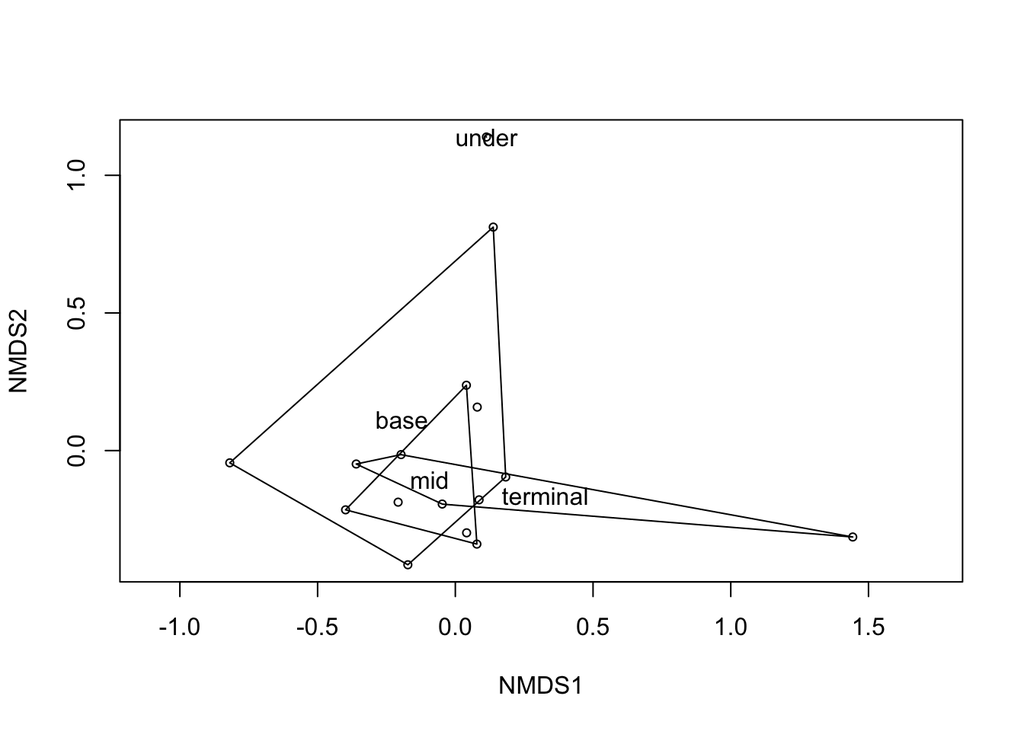

```r
plot(birds.mds2, disp = "sites")
ordihull(birds.mds2, birds.env$zone, label = T)
```

```r
# From this figure, it seems that the base of the tree has the
#   most different bird communities because this hull is the
#   largest and thus the plots are the most different.
#   The mid and terminal areas have more similar bird communities
#   because the hulls are smaller. Finally, a very different bird
#   community is found under the tree.
```

**Q14** For practice, also create a triplot that shows the spider diagrams for each zone and each height in separate figures.

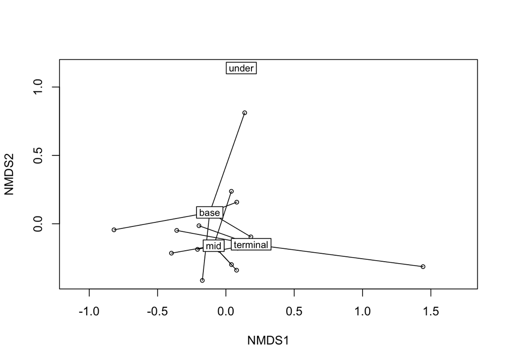

```r
plot(birds.mds2, disp = "sites")
ordispider(birds.mds2, birds.env$zone, label = T)
```

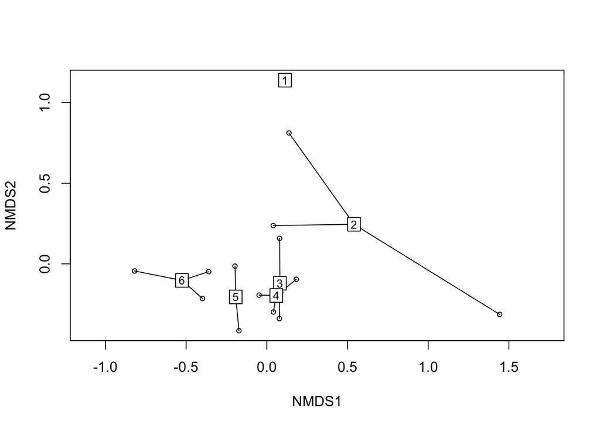

```r
plot(birds.mds2, disp = "sites")
ordispider(birds.mds2, birds.env$height, label = T)
```